# Data Analysis for Chronicle Project

Kevin Buffardi and Rahul Bijoor

2025-01-17

First, we will load the anonymized GitHub and survey data:

```r
github <- readr::read_csv("data/coded_collated_data.csv")
survey <- readr::read_csv("data/coded_survey_anonymous.csv")
```

At a glance, here are some descriptive statistics of our data:

- Total number of teams: **94**
- Total number of students: **465**

Summarize team trends:

```r
github_by_team <- github %>% select(Repository,Action) %>% pivot_wider(names_from = Action, values_from = Action, values_fn = length)
github_by_team <- github_by_team %>%
                  replace(is.na(.), 0) %>%
                  mutate(total = commit+pull_request+issue+comment+code_review)
```

- Trends, per team:
  - Commits (M = **133.9042553**, sd = **77.4891001**)
  - Pull requests (M = **22.4574468**, sd = **18.1769468**)
  - Issues (M = **21.0957447**, sd = **12.0358507**)
  - Comments (M = **5.1489362**, sd = **7.8342472**)
  - Code Reviews (M = **20.5319149**, sd = **27.9514564**)
  - Total artifacts (M = **203.1382979**, sd = **110.5271437**)

For each team, we need to calculate their aggregate score for **Conflict** and **Cohesiveness**, by finding the mean score of the answers of all of the members of the team (who responded).

- **Conflict**. Conflict questions include:
  - `How frequently do you have disagreements within your work group about the task of the project you are working on?`
  - `How often do people in your work group have conflicting opinions about the project you are working on?`
  - `How much emotional conflict is there in your work group?`
  - `How often do people get angry while working in your group?`
  - `How much conflict of ideas is there in your work group?`
  - `How often do you disagree about resource allocation in your work group?`
  - `How much relationship tension is there in your work group?`
  - `How often are there disagreements about who should do what in your work group?`
  - `How much conflict is there in your group about task responsibilities?`
- **Cohesiveness**. Cohesiveness questions include:
  - `Team members get to participate in enjoyable activities`
  - `Team members enjoy spending time together`
  - `Team members get along well`
  - `I'm unhappy with my team's level of commitment to the task` (inverse scale should be reversed by `6-x` where x is the raw value)
  - `Our team is united in trying to reach its goals for performance`
  - `Our team members have conflicting aspirations for the team's performance`
  - `Team members like each other`
  - `Team members like the work that the group does`
  - `Being part of the team allows team members to do enjoyable work`

```r
survey <- survey %>%
  mutate(
    Inverted_Unhappy = 6 - `I'm unhappy with my team's level of commitment to the task`
  )
conflict_columns <- c(
  "How frequently do you have disagreements within your work group about the task of the project you are working on?",
  "How often do people in your work group have conflicting opinions about the project you are working on?",
  "How much emotional conflict is there in your work group?",
  "How often do people get angry while working in your group?",
  "How much conflict of ideas is there in your work group?",
  "How often do you disagree about resource allocation in your work group?",
  "How much relationship tension is there in your work group?",
  "How often are there disagreements about who should do what in your work group?",
  "How much conflict is there in your group about task responsibilities?"
)

cohesiveness_columns <- c(
  "Team members get to participate in enjoyable activities",
  "Team members enjoy spending time together",
  "Team members get along well",
  "Inverted_Unhappy",
  "Our team is united in trying to reach its goals for performance",
  "Our team members have conflicting aspirations for the team's performance",
  "Team members like each other",
  "Team members like the work that the group does",
  "Being part of the team allows team members to do enjoyable work"
)



aggregate_scores <- survey %>%
  group_by(`Your Team`) %>%
  summarize(
    Conflict = mean(as.numeric(unlist(across(all_of(conflict_columns)))), na.rm = TRUE),
    Cohesiveness = mean(as.numeric(unlist(across(all_of(cohesiveness_columns)))), na.rm = TRUE)
  )
```

Then, we want to look at the descriptive statistics for these team conflict and cohesiveness scores:

- Team conflict (M = 1.5, sd = 0.37)
- Team cohesiveness (M = 3.79, sd = 0.4)

Next, we want to determine statistics about individuals:

```r
# For each individual, how many artifacts did they contribute per week:
github_by_individual <- github %>% select(Repository,Author,week) %>%
                        pivot_wider(names_from = week, values_from = week, values_fn = length) %>%
                        replace(is.na(.), 0) %>%
                        select(Repository,Author,`1`,`2`,`3`,`4`,`5`,`6`,`7`,`8`,`9`,`10`,`11`,`12`,`13`) %>%
                        mutate(activity=`1`+`2`+`3`+`4`+`5`+`6`+`7`+`8`+`9`+`10`+`11`+`12`+`13`) %>%
                        mutate(consistency = (as.integer(`1`>0)+as.integer(`2`>0)+as.integer(`3`>0)+as.integer(`4`>0)+as.integer(`5`>0)+as.integer(`6`>0)+as.integer(`7`>0)+as.integer(`8`>0)+as.integer(`9`>0)+as.integer(`10`>0)+as.integer(`11`>0)+as.integer(`12`>0)+as.integer(`13`>0))/13) %>%
                        filter(activity > 0)

individual_summary <- github_by_individual %>% select(Repository,Author,activity,consistency)
```

Let’s look at the median team statistics for artifacts and consistency as well as the parity (using the Gini index).

```r
team_gini <- individual_summary %>%
    group_by(Repository) %>%
    summarize(
        Gini_Artifacts = Gini(activity),
        Gini_Consistency = Gini(consistency),
        Median_Artifacts = median(activity),
        Median_Consistency = median(consistency)
    )
```

To determine the (in)equality within each team, we use [`Gini` from `DescTools`](https://search.r-project.org/CRAN/refmans/DescTools/html/Gini.html) to calculate the [Gini coefficient](https://en.wikipedia.org/wiki/Gini_coefficient). Low values (approaching 0) indicate equality while high values (approaching 1) represent inequality.

- Team Gini for total number of artifacts (M = 0.5129783, sd = 0.1666067)
- Team Gini for consistency (M = 0.3161176, sd = 0.1245557)

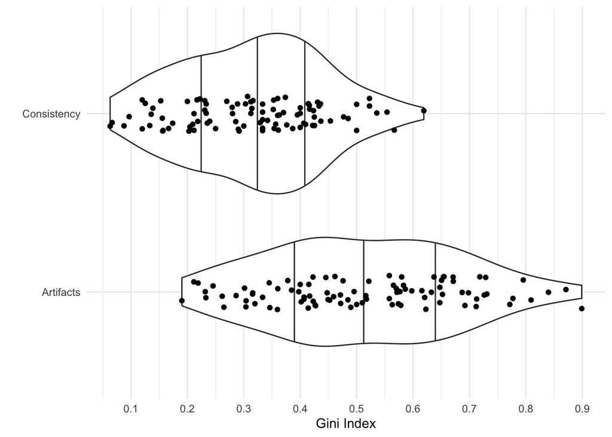

```r
gini <- team_gini %>%
             select("Repository","Gini_Artifacts","Gini_Consistency") %>%
             pivot_longer(cols = `Gini_Artifacts`:`Gini_Consistency`, names_to = "Measurement", values_to = "Gini Index")
gini_plot <- gini %>%
             ggplot(aes(`Gini Index`,`Measurement`)) +
               geom_violin(draw_quantiles = c(0.25, 0.5, 0.75)) +
               geom_jitter(height = 0.1, width = 0) +
               scale_x_continuous(breaks=seq(0,1,0.1)) +
               scale_y_discrete(
                 labels=c("Gini_Artifacts" = "Artifacts", "Gini_Consistency" = "Consistency"),
                 name = "") +
               theme_minimal()
gini_plot
```

```r
team_gini$Repository <- trimws(team_gini$Repository)
aggregate_scores$`Your Team` <- trimws(aggregate_scores$`Your Team`)
team_outcomes <- merge(x=team_gini,y=aggregate_scores, by.x = "Repository", by.y = "Your Team", all=TRUE)
```

Investigate correlations:

```r
quantity_v_conflict <- cor.test(team_outcomes$Gini_Artifacts,team_outcomes$Conflict, method = "spearman")
quantity_v_cohesiveness <- cor.test(team_outcomes$Gini_Artifacts,team_outcomes$Cohesiveness, method = "spearman")
consistency_v_conflict <- cor.test(team_outcomes$Gini_Consistency,team_outcomes$Conflict, method = "spearman")
consistency_v_cohesiveness <- cor.test(team_outcomes$Gini_Consistency,team_outcomes$Cohesiveness, method = "spearman")
```

What is the correlation between:

- Team Gini for total number of artifacts *vs* Team conflict (rho=0.0840674, p=0.4204816)
- Team Gini for total number of artifacts *vs* Team cohesiveness (rho=-0.0650441, p=0.5333845)
- Team Gini for consistency *vs* Team conflict (rho=0.0698322, p=0.5036187)
- Team Gini for consistency *vs* Team cohesiveness (rho=-0.1549069, p=0.1360145)

Are there students who have respectable activity counts, but poor consistency? Let’s look.

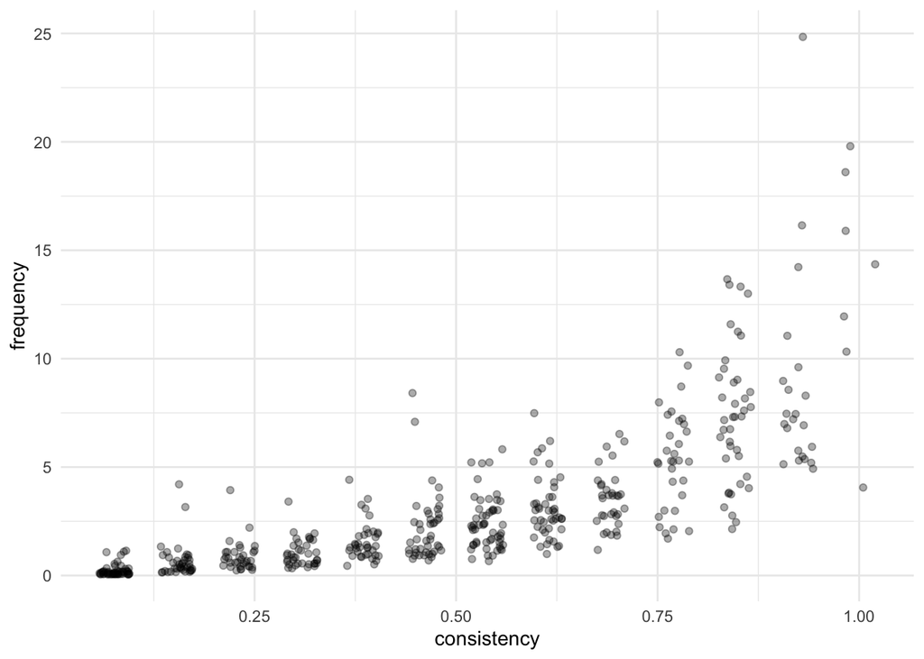

```r
github_by_individual$frequency <- github_by_individual$activity/13
ggplot(data=github_by_individual, aes(x=consistency, y=frequency, )) + geom_jitter(alpha=0.33, width = 0.02) + theme_minimal() + scale_size(range = c(1, 10))
```

While there is a likely correlation between the two, there is evidence of some students who do not contribute consistently but may make as “frequent” contributions as their counterparts who contribute on a consistent basis.

```r
summary(lm(data=team_outcomes, Cohesiveness~Median_Artifacts+Median_Consistency+Gini_Artifacts+Gini_Consistency))
```

```
##
## Call:
## lm(formula = Cohesiveness ~ Median_Artifacts + Median_Consistency +
##     Gini_Artifacts + Gini_Consistency, data = team_outcomes)
##
## Residuals:
##      Min       1Q   Median       3Q      Max
## -1.21460 -0.24510  0.03897  0.26781  0.77174
##
## Coefficients:
##                     Estimate Std. Error t value Pr(>|t|)
## (Intercept)         3.357863   0.252058  13.322  < 2e-16 ***
## Median_Artifacts   -0.004579   0.002997  -1.528  0.13014
## Median_Consistency  1.068272   0.376969   2.834  0.00569 **
## Gini_Artifacts     -0.027778   0.362330  -0.077  0.93906
## Gini_Consistency    0.219706   0.557874   0.394  0.69465
## ---
## Signif. codes:  0 '***' 0.001 '**' 0.01 '*' 0.05 '.' 0.1 ' ' 1
##
## Residual standard error: 0.3887 on 89 degrees of freedom
## Multiple R-squared:  0.09621,    Adjusted R-squared:  0.05559
## F-statistic: 2.369 on 4 and 89 DF,  p-value: 0.05857
```

```r
summary(lm(data=team_outcomes, Cohesiveness~Median_Consistency)) # eliminates factors with high p-values
```

```
##
## Call:
## lm(formula = Cohesiveness ~ Median_Consistency, data = team_outcomes)
##
## Residuals:
##      Min       1Q   Median       3Q      Max
## -1.37858 -0.22164  0.04018  0.29657  0.72119
##
## Coefficients:
##                    Estimate Std. Error t value Pr(>|t|)
## (Intercept)          3.5135     0.1164  30.176   <2e-16 ***
## Median_Consistency   0.5747     0.2289   2.511   0.0138 *
## ---
## Signif. codes:  0 '***' 0.001 '**' 0.01 '*' 0.05 '.' 0.1 ' ' 1
##
## Residual standard error: 0.3891 on 92 degrees of freedom
## Multiple R-squared:  0.06413,    Adjusted R-squared:  0.05396
## F-statistic: 6.304 on 1 and 92 DF,  p-value: 0.01379
```

```r
summary(lm(data=team_outcomes, Conflict~Median_Artifacts+Median_Consistency+Gini_Artifacts+Gini_Consistency))
```

```
##
## Call:
## lm(formula = Conflict ~ Median_Artifacts + Median_Consistency +
##     Gini_Artifacts + Gini_Consistency, data = team_outcomes)
##
## Residuals:
##     Min      1Q  Median      3Q     Max
## -0.6107 -0.2411 -0.0538  0.1176  1.3053
##
## Coefficients:
##                     Estimate Std. Error t value Pr(>|t|)
## (Intercept)         1.508874   0.234858   6.425 6.34e-09 ***
## Median_Artifacts    0.007218   0.002793   2.584   0.0114 *
## Median_Consistency -0.666864   0.351245  -1.899   0.0609 .
## Gini_Artifacts      0.054894   0.337605   0.163   0.8712
## Gini_Consistency    0.201037   0.519806   0.387   0.6999
## ---
## Signif. codes:  0 '***' 0.001 '**' 0.01 '*' 0.05 '.' 0.1 ' ' 1
##
## Residual standard error: 0.3622 on 89 degrees of freedom
## Multiple R-squared:  0.07658,    Adjusted R-squared:  0.03508
## F-statistic: 1.845 on 4 and 89 DF,  p-value: 0.1272
```

```r
summary(lm(data=team_outcomes, Conflict~Median_Artifacts+Median_Consistency)) # eliminates factors with high p-values
```

```
##
## Call:
## lm(formula = Conflict ~ Median_Artifacts + Median_Consistency,
##     data = team_outcomes)
##
## Residuals:
##      Min       1Q   Median       3Q      Max
## -0.63052 -0.25577 -0.06851  0.12492  1.32436
##
## Coefficients:
##                     Estimate Std. Error t value Pr(>|t|)
## (Intercept)         1.645168   0.112480   14.63   <2e-16 ***
## Median_Artifacts    0.006691   0.002593    2.58   0.0115 *
## Median_Consistency -0.727651   0.312236   -2.33   0.0220 *
## ---
## Signif. codes:  0 '***' 0.001 '**' 0.01 '*' 0.05 '.' 0.1 ' ' 1
##
## Residual standard error: 0.3591 on 91 degrees of freedom
## Multiple R-squared:  0.07202,    Adjusted R-squared:  0.05162
## F-statistic: 3.531 on 2 and 91 DF,  p-value: 0.03335
```

Post-hoc analysis of slackers:

```r
slackers <- github_by_individual
slackers <- slackers %>% filter(consistency == (1/13)) %>% mutate(lone="mid")
slackers$lone[slackers$`1` | slackers$`2`] <- "early"
slackers$lone[slackers$`12` | slackers$`13`] <- "late"
```

There were **55** individuals who only showed github activities during one week of the semester.

- They belonged to **38** teams
- Their activities were relatively low during that week (M=**2.8909091**, sd=**3.4623516**)
- **24** only contributed in the first 2 weeks of the semester
- **15** only contributed in the final 2 weeks of the semester
- **16** only contributed in the middle 9 weeks of the semester

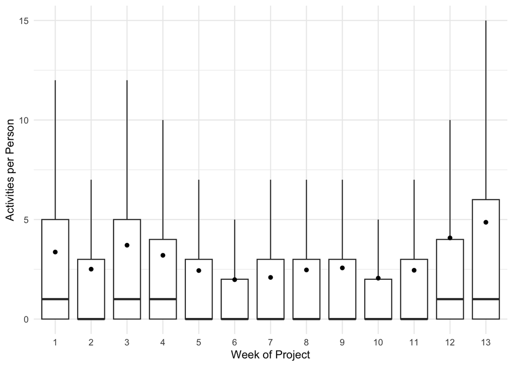

```r
slackers_by_team <- slackers %>%
                    select(Repository,lone) %>%
                    group_by(Repository) %>%
                    pivot_wider(names_from = lone, values_from = lone, values_fn = length)
slacker_outcomes <- merge(x=team_outcomes,y=slackers_by_team, by = "Repository", all.x=TRUE) %>%
                    replace(is.na(.), 0) %>%
                    merge(y=github_by_team, by = "Repository", all = TRUE)

activities_by_week_plot <- github_by_individual %>%
                           select(`1`:`13`) %>%
                           pivot_longer(cols = `1`:`13`, names_to = "Week", values_to = "GitHub Activities") %>%
                           ggplot(
                             aes( x=factor(Week,
                                 levels=c("1","2","3","4","5","6","7","8","9","10","11","12","13")),
                                 y=`GitHub Activities`)) +
                             geom_boxplot(outliers=FALSE) +
                             stat_summary(fun=mean, geom="point") +
                             labs(x="Week of Project",y="Activities per Person") +
                             theme_minimal()
activities_by_week_plot
```